# Detector Dog CBARQ with Phase 1 and Phase 2 Data

V 1.0 Both Data Sets and No Chasing Questions

Liz Hare

2023-08-15

# 1 Data and Code

The R code for the analysis of the combined Phase 1 and Phase 2 data are in a [GitHub repository](https://github.com/LizHareDogs/detectorCBARQ). This repository is private for now; send me a request to access it with your GitHub user ID at lizhare@gmail.com. The goal is open the code for peer review and the community.

Two spreadsheets received from James are imported:

- Phase 1: `Detection-dog-survey.xlsx`
- Phase 2: `DD Survey 20220714-20221104.xlsx`

# 2 Demographic Description

The data analyzed here include 1117 dogs with dogs collected in Phase 1 (686 dogs) and Phase 2 (431 dogs). In phase 1, there was a problem collecting data about whether dogs were neutered. Also in phase 1, three questions about chasing were excluded. Because they are missing fro most dogs in this data set, they are excluded from the whole analysis (previous analysis of Phase 2 shows the three chasing items separate into a factor).

After merging the data from Phase 1 and Phase 2, we found that 58 dogs had repeated records. 56 were removed by selecting the record with the latest date, because they will have better data on neutering. Two repeated records were completed on the same day, so the ones with fewer missing CBARQ items were retained.

## 2.1 Sex and Neuter Status

Overall Sex and Neuter Status (Caution: lots of missing neuter status data)

| **Characteristic** | **Overall**, N = 1,117<sup>1</sup> | **no**, N = 213<sup>1</sup> | **unknown**, N = 627<sup>1</sup> | **yes**, N = 277<sup>1</sup> |
| --- | --- | --- | --- | --- |
| sexF |  |  |  |  |
| female | 486 (44%) | 58 (27%) | 276 (44%) | 152 (55%) |
| male | 631 (56%) | 155 (73%) | 351 (56%) | 125 (45%) |

<sup>1</sup> n (%)

Sex and Neuter Status by Phase(Caution lots of missing neuter status data in Phase 1_

| **Characteristic** | **1** **female**, N = 307<sup>1</sup> | **1** **male**, N = 379<sup>1</sup> | **2** **female**, N = 179<sup>1</sup> | **2** **male**, N = 252<sup>1</sup> |
| --- | --- | --- | --- | --- |
| neuteredF |  |  |  |  |
| no | 8 (2.6%) | 12 (3.2%) | 50 (28%) | 143 (57%) |
| unknown | 276 (90%) | 351 (93%) | 0 (0%) | 0 (0%) |
| yes | 23 (7.5%) | 16 (4.2%) | 129 (72%) | 109 (43%) |

<sup>1</sup> n (%)

## 2.2 Breed and Breed Group

The questionnaire provided a multiple-choice question asking about the dog’s breed. We assigned breeds to [AKC breed groups](https://www.akc.org/public-education/resources/general-tips-information/dog-breeds-sorted-groups/) to potentially avoid having a large number of categories with small numbers of dogs. If a breed was not listed with AKC, breeds, groups were chosen according to the breed’s purpose and history.

Overall, there were 886 purebred dogs. There were 92 dogs listed as “cross-breed” (*were there instructions to use this specifically for known crosses like labradoodles?*) and 70 dogslisted as “mixed-breed.”

### 2.2.1 Breed

| **Characteristic** | **N = 1,117**<sup>1</sup> |
| --- | --- |
| Breed |  |
| Airedale Terrier | 1 (<0.1%) |
| Akita | 1 (<0.1%) |
| Alaskan Malamute | 1 (<0.1%) |
| American Coonhound | 2 (0.2%) |
| American Indian Dog | 1 (<0.1%) |
| American Pit Bull Terrier | 5 (0.4%) |
| American Water Spaniel | 1 (<0.1%) |
| Anatolian Shepherd | 2 (0.2%) |
| Australian Cattle Dog | 8 (0.7%) |
| Australian Kelpie | 7 (0.6%) |
| Australian Koolie | 2 (0.2%) |
| Australian Shepherd | 17 (1.5%) |
| Australian Shepherd (Miniature) | 2 (0.2%) |
| Beagle | 2 (0.2%) |
| Beauceron | 1 (<0.1%) |
| Belgian Groenendael | 1 (<0.1%) |
| Belgian Malinois | 123 (11%) |
| Belgian Malinois x Dutch Shepherd cross | 1 (<0.1%) |
| Belgian Sheepdog | 1 (<0.1%) |
| Belgian Tervuren | 6 (0.5%) |
| Berger Blanc Suisse (Swiss Shepherd Dog) | 1 (<0.1%) |
| Bernese Mountain Dog | 2 (0.2%) |
| Black and Tan Coonhound | 1 (<0.1%) |
| Bloodhound | 8 (0.7%) |
| Blue Tick Coonhound | 1 (<0.1%) |
| Border Collie | 45 (4.0%) |
| Border Terrier | 2 (0.2%) |
| Bouvier des Flandres | 2 (0.2%) |
| Boxer | 3 (0.3%) |

[output cut: 77 more lines]

<sup>1</sup> n (%)

### 2.2.2 Breed Group

| Breed Group | N (Percent)<sup>1</sup> |
| --- | --- |
| breedGroup |  |
| Herding | 449 (50.7%) |
| Hound | 12 (1.4%) |
| Non-Sporting | 9 (1.0%) |
| Sporting | 382 (43.1%) |
| Terrier | 12 (1.4%) |
| Toy | 1 (0.1%) |
| Working | 21 (2.4%) |
| Unknown | 231 |

<sup>1</sup> n (%)

## 2.3 Country

| **Characteristic** | **N = 1,117**<sup>1</sup> |
| --- | --- |
| Country |  |
| Australia | 23 (2.1%) |
| Belgium | 2 (0.2%) |
| Brazil | 1 (<0.1%) |
| Canada | 48 (4.3%) |
| Colombia | 1 (<0.1%) |
| Croatia | 1 (<0.1%) |
| France | 6 (0.5%) |
| Germany | 6 (0.5%) |
| Italy | 6 (0.5%) |
| Japan | 1 (<0.1%) |
| Mexico | 1 (<0.1%) |
| Netherlands | 6 (0.5%) |
| New Zealand | 6 (0.5%) |
| Norway | 1 (<0.1%) |
| Philippines | 1 (<0.1%) |
| Poland | 2 (0.2%) |
| Slovakia | 1 (<0.1%) |
| South Africa | 2 (0.2%) |
| Spain | 1 (<0.1%) |
| Sweden | 7 (0.6%) |
| Switzerland | 4 (0.4%) |
| Thailand | 1 (<0.1%) |
| United Kingdom | 18 (1.6%) |
| United States | 971 (87%) |

<sup>1</sup> n (%)

## 2.4 Age, Training, and Retirement

Univariate Statistics for Age in Years

|  | vars | n | mean | sd | median | trimmed | mad | min | max | range | skew | kurtosis | se |
| --- | --- | --- | --- | --- | --- | --- | --- | --- | --- | --- | --- | --- | --- |
| X1 | 1 | 1117 | 4.82 | 3.32 | 4 | 4.55 | 2.97 | 0.17 | 18.99 | 18.82 | 0.68 | -0.03 | 0.1 |

| **Characteristic** | **Overall**, N = 1,117<sup>1</sup> | **training**, N = 198<sup>1</sup> | **working**, N = 815<sup>1</sup> | **retired**, N = 104<sup>1</sup> |
| --- | --- | --- | --- | --- |
| ageY | 4.82 (3.32) (0.17 - 18.99) | 2.63 (2.07) (0.17 - 12.99) | 4.82 (2.94) (0.17 - 18.99) | 8.97 (4.04) (0.50 - 15.99) |

<sup>1</sup> Mean (SD) (Range)

### 2.4.1 Dual Purpose

There are 234 dual purpose dogs (21%).

#### 2.4.1.1 What breeds are dually trained?

From some of the breeds that show up in this table, I suspect these handlers aren’t defining “dual purpose” the same way PVWDC does (Golden Retriever, Cocker Spaniel…).

| **Characteristic** | **N = 234**<sup>1</sup> |
| --- | --- |
| breedF |  |
| Airedale Terrier | 0, (0.0%) |
| Akita | 0, (0.0%) |
| Alaskan Malamute | 0, (0.0%) |
| American Coonhound | 0, (0.0%) |
| American Indian Dog | 1, (0.4%) |
| American Pit Bull Terrier | 0, (0.0%) |
| American Water Spaniel | 0, (0.0%) |
| Australian Cattle Dog | 0, (0.0%) |
| Australian Kelpie | 1, (0.4%) |
| Australian Koolie | 0, (0.0%) |
| Australian Shepherd | 1, (0.4%) |
| Australian Shepherd (Miniature) | 0, (0.0%) |
| Beagle | 0, (0.0%) |
| Belgian Groenendael | 0, (0.0%) |
| Belgian Malinois | 46, (19.7%) |
| Belgian Sheepdog | 0, (0.0%) |
| Belgian Tervuren | 0, (0.0%) |
| Berger Blanc Suisse (Swiss Shepherd Dog) | 0, (0.0%) |
| Bernese Mountain Dog | 0, (0.0%) |
| Black and Tan Coonhound | 0, (0.0%) |
| Bloodhound | 2, (0.9%) |
| Blue Tick Coonhound | 0, (0.0%) |
| Border Collie | 11, (4.7%) |
| Border Terrier | 0, (0.0%) |
| Bouvier des Flandres | 1, (0.4%) |
| Boxer | 0, (0.0%) |
| Boykin Spaniel | 0, (0.0%) |
| Briard | 0, (0.0%) |
| Brittany | 0, (0.0%) |

[output cut: 77 more lines]

<sup>1</sup> n, (%)

## 2.5 Odors Detected

| Type of Trained Odor | N (Percent)<sup>1</sup> |
| --- | --- |
| Accelerant | 17 (1.5%) |
| Contraband | 15 (1.3%) |
| Endangered Species | 26 (2.3%) |
| Explosives | 112 (10.0%) |
| Human Remains | 372 (33.3%) |
| Invasive Species | 18 (1.6%) |
| Live Human Air Scent | 322 (28.8%) |
| Live Human Tracking | 234 (20.9%) |
| Medical Detection | 21 (1.9%) |
| Narcotics | 146 (13.1%) |
| Pests | 29 (2.6%) |
| Other | 247 (22.1%) |

<sup>1</sup> n (%)

### 2.5.1 Odors entered under “Other”

There are too many responses to print here (247). Lots of them are nosework-related. Let me know if you want the list.

## 2.6 Certification

| Certifying Organization | N (Percent)<sup>1</sup> |
| --- | --- |
| American Rescue Dog Association | 10 (0.9%) |
| Federal Emergency Management Agency | 108 (9.7%) |
| National Association for Search and Rescue | 89 (8.0%) |
| National Entomology Scent Detection Canine Association | 5 (0.4%) |
| National Narcotic Detector Dog Association | 40 (3.6%) |
| National Tactical Police Dog Association | 2 (0.2%) |
| North American Police Dog Association | 62 (5.6%) |
| Search and Rescue Dogs of the United States | 26 (2.3%) |
| United States Police Dog Association | 40 (3.6%) |

<sup>1</sup> n (%)

### 2.6.1 Other Certifying organizations

There are too many answers to print here (569).

## 2.7 Alert Type

| Alert Type | N (Percent)<sup>1</sup> |
| --- | --- |
| alerttypeF |  |
| Bark | 266, (23.8%) |
| Down | 155, (13.9%) |
| Other | 159, (14.2%) |
| Scratch | 49, (4.4%) |
| Sit | 336, (30.1%) |
| Stare | 152, (13.6%) |

<sup>1</sup> n, (%)

## 2.8 Reward System

| **Characteristic** | **N = 1,117**<sup>1</sup> |
| --- | --- |
| rewardsystemF |  |
| food | 362, 32.4% |
| praise | 25, 2.2% |
| toy (fetch) | 246, 22.0% |
| toy (tug) | 484, 43.3% |

<sup>1</sup> n, %

## 2.9 Handler Experience

Experience is measured by the number of dogs handled before the current one.

| **Characteristic** | **N = 1,117**<sup>1</sup> |
| --- | --- |
| dogshandledbeforeF |  |
| 0 | 363, 32.5% |
| 1 to 2 | 405, 36.3% |
| 3 to 5 | 197, 17.6% |
| more than 5 | 152, 13.6% |

<sup>1</sup> n, %

## 2.10 Dogs’ Home Environment

| **Characteristic** | **N = 1,117**<sup>1</sup> |
| --- | --- |
| dogshomelocationF |  |
| in my house kenneled | 224, 20.1% |
| in my house unkenneled | 814, 72.9% |
| in my organization's kennel | 13, 1.2% |
| in my yard kenneled | 56, 5.0% |
| other | 10, 0.9% |

<sup>1</sup> n, %

## 2.11 Owner Rating of Scent Work Ability and General Behavior and Temperament

### 2.11.1 Scent Work

Owners’ Rating of Dogs’ Scent Detection Work Ability

|  | vars | n | mean | sd | median | trimmed | mad | min | max | range | skew | kurtosis | se |
| --- | --- | --- | --- | --- | --- | --- | --- | --- | --- | --- | --- | --- | --- |
| X1 | 1 | 1116 | 8.5 | 1.22 | 9 | 8.6 | 1.48 | 1 | 10 | 9 | -1.13 | 3.15 | 0.04 |

### 2.11.2 General Behavior and Temperament

Owners’ Rating of Dogs’ General Behavior and Temperament

|  | vars | n | mean | sd | median | trimmed | mad | min | max | range | skew | kurtosis | se |
| --- | --- | --- | --- | --- | --- | --- | --- | --- | --- | --- | --- | --- | --- |
| X1 | 1 | 1115 | 8.53 | 1.41 | 9 | 8.71 | 1.48 | 0 | 10 | 10 | -1.49 | 4.08 | 0.04 |

### 2.11.3 Are Scent Work and Behavior Assessment Correlated?

The correlation between scenting ability and general behavior is 0.53.

## 2.12 DNA Sample Availability

There were 1019 owners willing to provide DNA samples (91%).

# 3 CBARQ Items’ Descriptive Statistics and Plots

Descriptive Statistics for Detector-C-BARQ Items

|  | NMissing | Mean | SD | Min | Max | Skewness | Kurtosis | Shapiro-Wilk Score | Shapiro-Wilk p |
| --- | --- | --- | --- | --- | --- | --- | --- | --- | --- |
| TRAIN01 | 15 | 1.08 | 0.81 | 0 | 4 | 0.63 | 0.60 | 0.84 | 9.655306e-32 |
| TRAIN02 | 5 | 0.92 | 0.74 | 0 | 4 | 0.77 | 1.41 | 0.81 | 1.449781e-34 |
| TRAIN03 | 21 | 1.18 | 0.85 | 0 | 4 | 0.54 | 0.33 | 0.86 | 2.808713e-30 |
| TRAIN04 | 3 | 0.86 | 0.67 | 0 | 3 | 0.38 | 0.02 | 0.80 | 3.703645e-35 |
| TRAIN05 | 45 | 0.93 | 0.91 | 0 | 4 | 0.84 | 0.42 | 0.83 | 2.650988e-32 |
| TRAIN06 | 12 | 0.62 | 0.68 | 0 | 4 | 0.96 | 1.22 | 0.75 | 9.812663e-38 |
| TRAIN07 | 0 | 1.07 | 0.79 | 0 | 4 | 0.37 | -0.21 | 0.85 | 2.169221e-31 |
| TRAIN08 | 9 | 0.63 | 1.11 | 0 | 4 | 1.79 | 2.22 | 0.62 | 8.418851e-44 |
| AGG09 | 5 | 0.18 | 0.51 | 0 | 4 | 3.93 | 19.58 | 0.38 | 1.220653e-51 |
| AGG10 | 0 | 0.56 | 0.87 | 0 | 4 | 1.72 | 2.83 | 0.68 | 1.469412e-41 |
| AGG11 | 12 | 0.08 | 0.33 | 0 | 4 | 5.44 | 36.75 | 0.24 | 4.800148e-55 |
| AGG12 | 8 | 0.06 | 0.32 | 0 | 3 | 5.94 | 39.28 | 0.20 | 5.713450e-56 |
| AGG13 | 32 | 0.07 | 0.39 | 0 | 4 | 6.99 | 55.84 | 0.18 | 5.587363e-56 |
| AGG14 | 10 | 0.63 | 0.75 | 0 | 4 | 1.24 | 1.69 | 0.75 | 4.134448e-38 |
| AGG15 | 18 | 0.19 | 0.60 | 0 | 4 | 4.09 | 18.92 | 0.36 | 4.234352e-52 |
| AGG16 | 12 | 0.63 | 0.87 | 0 | 4 | 1.65 | 2.95 | 0.71 | 7.268859e-40 |
| AGG17 | 12 | 0.06 | 0.29 | 0 | 4 | 7.24 | 71.62 | 0.19 | 5.385032e-56 |
| AGG18 | 35 | 1.10 | 1.12 | 0 | 4 | 0.92 | 0.12 | 0.83 | 4.719855e-32 |
| AGG19 | 21 | 0.22 | 0.55 | 0 | 4 | 3.35 | 14.17 | 0.44 | 7.828654e-50 |
| AGG20 | 50 | 0.47 | 0.78 | 0 | 4 | 2.00 | 4.60 | 0.64 | 1.700955e-42 |
| FEAR21 | 17 | 0.23 | 0.56 | 0 | 4 | 3.04 | 11.04 | 0.46 | 2.166957e-49 |
| FEAR22 | 13 | 0.52 | 0.86 | 0 | 4 | 1.96 | 3.90 | 0.64 | 6.331022e-43 |
| FEAR23 | 28 | 0.23 | 0.56 | 0 | 4 | 2.96 | 10.68 | 0.47 | 7.401603e-49 |
| FEAR24 | 24 | 0.27 | 0.61 | 0 | 4 | 2.79 | 9.12 | 0.49 | 4.035360e-48 |
| FEAR25 | 10 | 0.20 | 0.53 | 0 | 4 | 3.49 | 15.47 | 0.42 | 1.678558e-50 |
| FEAR26 | 17 | 0.62 | 0.88 | 0 | 4 | 1.57 | 2.35 | 0.71 | 7.574245e-40 |
| FEAR27 | 29 | 0.52 | 0.74 | 0 | 4 | 1.59 | 2.83 | 0.69 | 1.294666e-40 |
| FEAR28 | 9 | 0.35 | 0.60 | 0 | 4 | 1.89 | 4.41 | 0.61 | 2.215563e-44 |
| FEAR29 | 19 | 0.66 | 0.82 | 0 | 4 | 1.36 | 2.07 | 0.75 | 7.562087e-38 |
| FEAR30 | 13 | 0.37 | 0.63 | 0 | 4 | 2.05 | 5.84 | 0.61 | 2.493507e-44 |
| FEAR31 | 53 | 0.79 | 0.89 | 0 | 4 | 1.04 | 0.66 | 0.79 | 1.030109e-34 |
| SEPR32 | 16 | 0.62 | 0.94 | 0 | 4 | 1.51 | 1.64 | 0.70 | 1.456687e-40 |
| SEPR33 | 14 | 0.84 | 0.96 | 0 | 4 | 1.00 | 0.40 | 0.80 | 4.779081e-35 |
| SEPR34 | 16 | 0.29 | 0.65 | 0 | 4 | 2.51 | 6.53 | 0.51 | 6.895010e-48 |
| EXCITE35 | 17 | 2.04 | 1.06 | 0 | 4 | -0.20 | -0.68 | 0.91 | 2.640374e-25 |
| EXCITE36 | 17 | 2.20 | 0.98 | 0 | 4 | -0.47 | -0.32 | 0.88 | 5.274969e-28 |
| EXCITE37 | 22 | 1.92 | 1.05 | 0 | 4 | 0.03 | -0.73 | 0.91 | 7.649087e-25 |
| EXCITE38 | 21 | 2.41 | 1.02 | 0 | 4 | -0.52 | -0.27 | 0.89 | 1.090840e-27 |
| ATT39 | 21 | 3.15 | 1.00 | 0 | 4 | -1.06 | 0.41 | 0.79 | 2.958991e-35 |
| ATT40 | 23 | 0.70 | 0.90 | 0 | 4 | 1.43 | 2.01 | 0.75 | 6.071451e-38 |
| ATT41 | 21 | 1.73 | 1.15 | 0 | 4 | 0.17 | -0.69 | 0.91 | 8.328397e-25 |
| ATT42 | 29 | 1.08 | 1.06 | 0 | 4 | 0.75 | -0.13 | 0.84 | 2.496265e-31 |
| PLAY43 | 38 | 2.96 | 1.13 | 0 | 4 | -1.02 | 0.26 | 0.81 | 1.858605e-33 |
| PLAY44 | 28 | 3.17 | 1.19 | 0 | 4 | -1.31 | 0.62 | 0.72 | 2.666095e-39 |
| PLAY45 | 32 | 3.18 | 1.12 | 0 | 4 | -1.32 | 0.85 | 0.74 | 3.087604e-38 |
| PLAY46 | 36 | 3.38 | 1.02 | 0 | 4 | -1.79 | 2.50 | 0.65 | 2.963994e-42 |
| IMP47 | 32 | 1.42 | 0.88 | 0 | 4 | 0.32 | -0.07 | 0.88 | 4.726709e-28 |
| IMP48 | 33 | 1.04 | 0.82 | 0 | 4 | 0.66 | 0.52 | 0.84 | 1.375901e-31 |
| IMP49 | 31 | 1.46 | 0.93 | 0 | 4 | 0.50 | 0.08 | 0.88 | 5.181349e-28 |
| MISC50 | 448 | 0.79 | 1.06 | 0 | 4 | 1.20 | 0.40 | 0.74 | 6.079695e-31 |
| MISC51 | 67 | 0.54 | 0.91 | 0 | 4 | 1.84 | 3.04 | 0.65 | 5.828757e-42 |
| MISC52 | 64 | 1.21 | 1.17 | 0 | 4 | 0.77 | -0.28 | 0.85 | 2.831922e-30 |
| MISC53 | 66 | 0.79 | 1.02 | 0 | 4 | 1.27 | 1.01 | 0.76 | 8.306130e-37 |
| MISC54 | 39 | 0.56 | 0.78 | 0 | 4 | 1.36 | 1.63 | 0.72 | 2.609030e-39 |
| MISC55 | 41 | 0.25 | 0.62 | 0 | 4 | 2.98 | 10.37 | 0.46 | 8.496991e-49 |
| MISC56 | 41 | 0.39 | 0.70 | 0 | 4 | 2.00 | 4.16 | 0.60 | 3.149371e-44 |
| MISC57 | 41 | 1.57 | 1.05 | 0 | 4 | 0.28 | -0.46 | 0.90 | 2.073455e-25 |
| MISC58 | 46 | 0.17 | 0.52 | 0 | 4 | 3.83 | 17.35 | 0.37 | 2.217191e-51 |
| MISC59 | 37 | 0.83 | 0.92 | 0 | 4 | 0.97 | 0.53 | 0.80 | 2.528656e-34 |
| MISC60 | 40 | 2.39 | 1.01 | 0 | 4 | -0.27 | -0.28 | 0.90 | 1.086574e-25 |
| MISC61 | 40 | 2.78 | 0.97 | 0 | 4 | -0.53 | -0.22 | 0.88 | 2.092420e-28 |
| MISC62 | 41 | 1.42 | 1.08 | 0 | 4 | 0.58 | -0.21 | 0.89 | 2.327415e-27 |
| MISC63 | 42 | 1.09 | 0.95 | 0 | 4 | 0.73 | 0.26 | 0.86 | 2.651403e-30 |
| MISC64 | 51 | 0.99 | 0.85 | 0 | 4 | 0.94 | 1.30 | 0.82 | 1.073411e-32 |
| MISC65 | 38 | 0.97 | 0.75 | 0 | 4 | 0.65 | 0.95 | 0.82 | 4.054022e-33 |
| MISC66 | 40 | 0.56 | 0.68 | 0 | 4 | 1.11 | 1.41 | 0.73 | 1.950999e-38 |
| MISC67 | 39 | 0.46 | 0.62 | 0 | 4 | 1.31 | 2.15 | 0.68 | 9.185168e-41 |
| MISC68 | 39 | 0.12 | 0.44 | 0 | 4 | 4.64 | 24.90 | 0.29 | 2.132719e-53 |
| MISC69 | 50 | 0.17 | 0.61 | 0 | 4 | 4.14 | 18.06 | 0.31 | 1.166681e-52 |
| MISC70 | 38 | 1.05 | 1.08 | 0 | 4 | 0.83 | -0.06 | 0.84 | 5.926984e-32 |
| MISC71 | 40 | 0.52 | 0.88 | 0 | 4 | 1.85 | 3.10 | 0.64 | 9.553892e-43 |

The number of dogs in this analysis is 1117. To use mean or mode imputation, < 5% of the data should be missing. Items should have no more than 55.85 missing if these kinds of imputations will be used.

Items with > 5 percent missing

[output not shown]

According to Watkins (2021), items should be removed if they have skewness > 2.0 or kurtosis > 7.0. These items would violate the assumptions of the Pearson correlation coefficients that factor analysis is based on. (Do we need to consider the items as ordinal discrete values?)

There are 17 items with skewness > 2.0 including AGG09, AGG11, AGG12, AGG13, AGG15, AGG17, AGG19, FEAR21, FEAR23, FEAR24, FEAR25, FEAR30, SEPR34, MISC55, MISC58, MISC68, MISC69.

There are 15 items with kurtosis > 7.0 including AGG09, AGG11, AGG12, AGG13, AGG15, AGG17, AGG19, FEAR21, FEAR23, FEAR24, FEAR25, MISC55, MISC58, MISC68, MISC69

For the current data set, 17 items would be removed for the factor analysis.

### 3.0.1 Count Plots

#### 3.0.1.1 Trainability

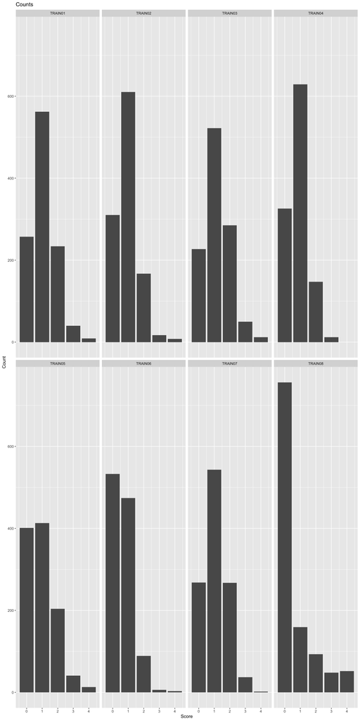

#### 3.0.1.2 Aggression

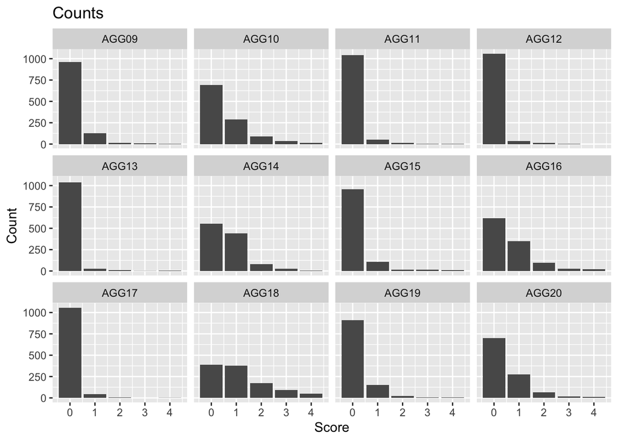

#### 3.0.1.3 Fear

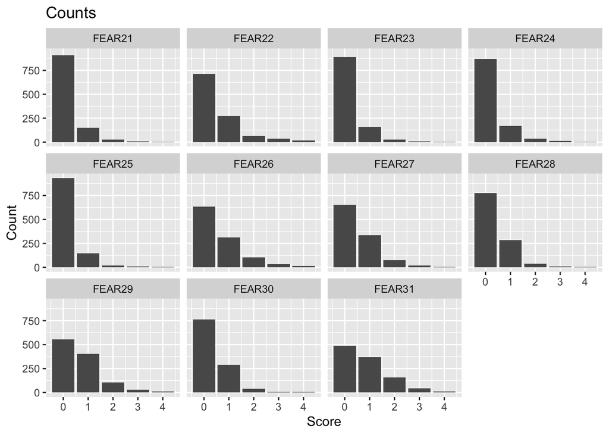

#### 3.0.1.4 Separation

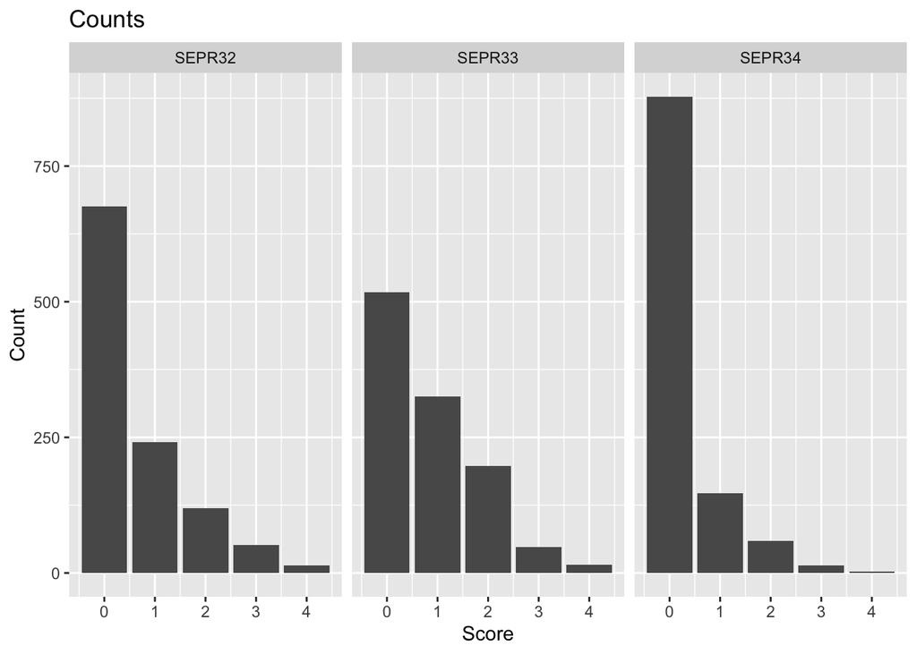

#### 3.0.1.5 Excitability

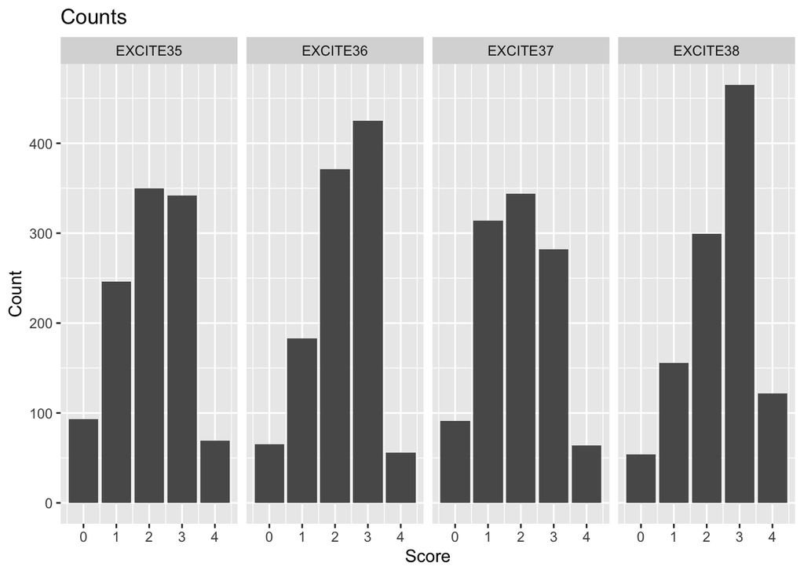

#### 3.0.1.6 Attention-Seeking

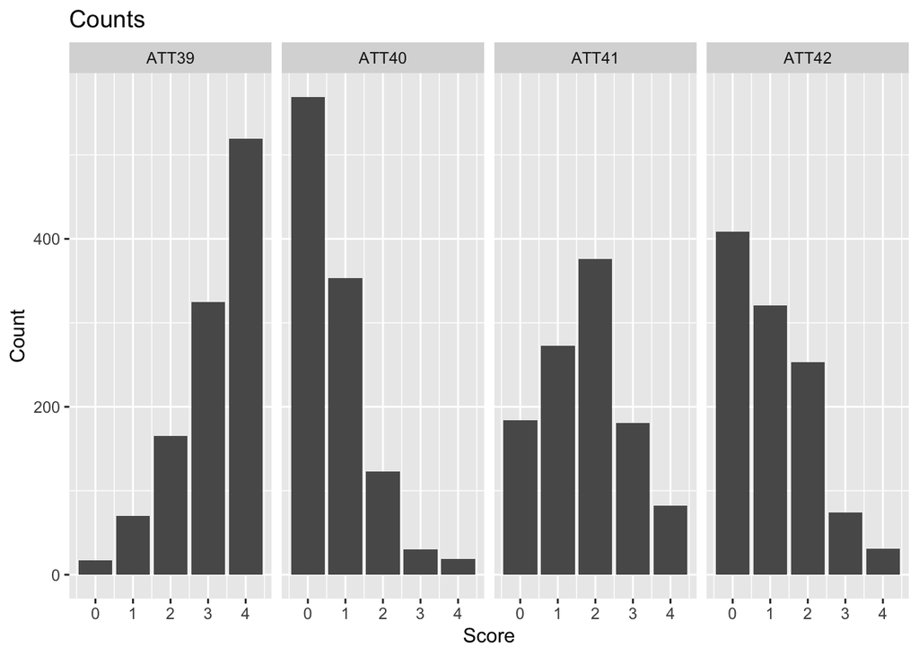

#### 3.0.1.7 Play

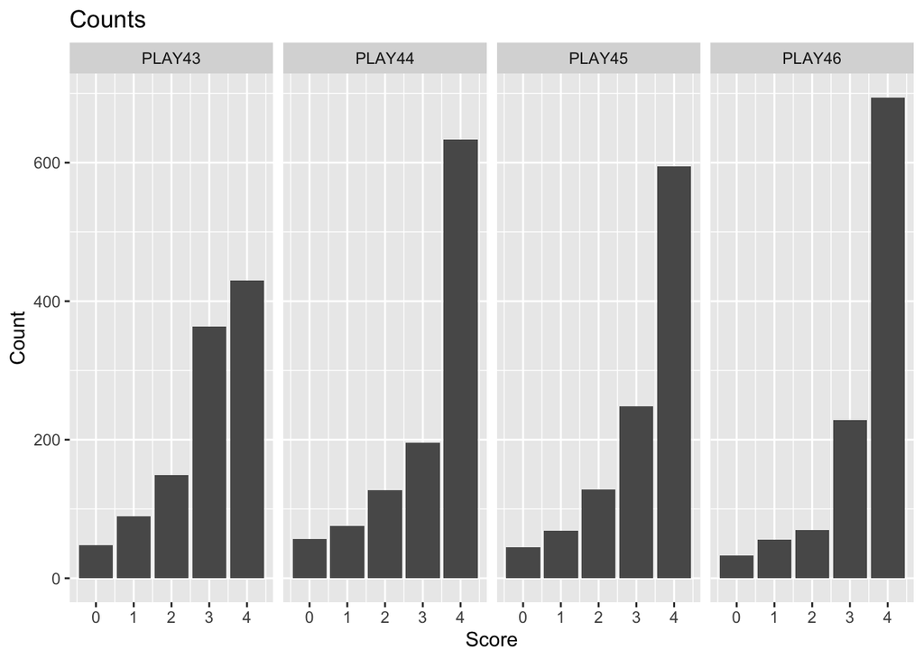

#### 3.0.1.8 Impulsivity

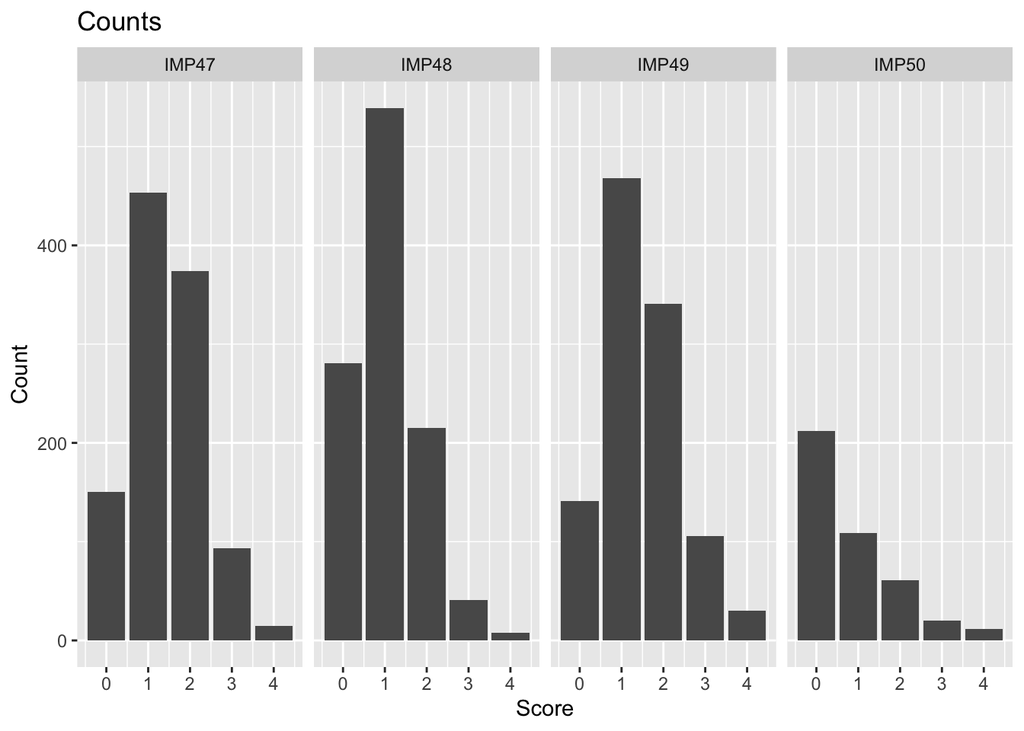

#### 3.0.1.9 Miscellaneous

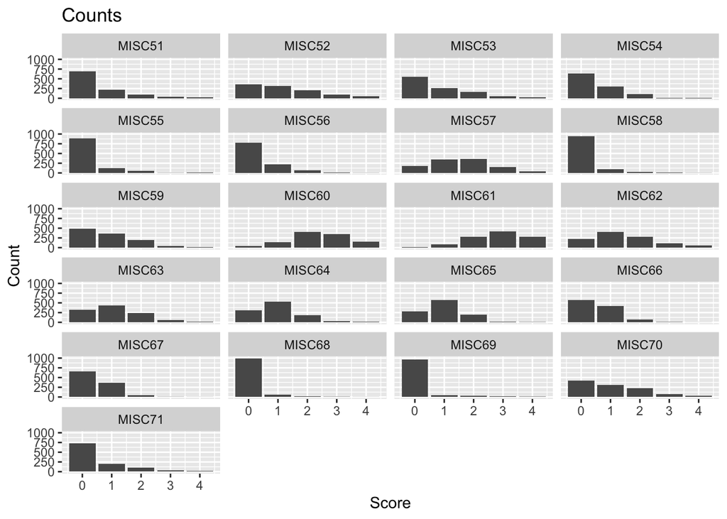

# 4 Conclusions for Factor Analysis

Data will ba analyzed with the items as **ordered factors** rather than numeric variables for the following reasons:

- Many items have a large number of values of 0
- The p-value for the Shapiro test is always near 0, indicating that the data do not come from a normal distribution.
- Some items have high skewness and kurtosis. The kurtosis is particularly high for some of the items.